# A new rapid resazurin-based microdilution assay for antimicrobial susceptibility testing of Neisseria gonorrhoeae

### Coefficient of variation

| strain | antibiotic | MIC | mean | sd | CV |
| --- | --- | --- | --- | --- | --- |
| WHO F | Azithromycin | 0.125 | 0.01394 | 0.009803 | 0.7031 |
| WHO F | Cefixime | <0.016 | 0.0005485 | 4.743e-05 | 0.08647 |
| WHO F | Ceftriaxone | <0.002 | 0.0002095 | 0.0001515 | 0.7231 |
| WHO F | Ciprofloxacin | 0.004 | 0.002442 | 0.0003445 | 0.141 |
| WHO F | Penicillin | 0.032 | 0.005978 | 0.0005169 | 0.08648 |
| WHO F | Spectinomycin | 16 | 3.141 | 2.253 | 0.7174 |
| WHO F | Tetracycline | 0.25 | 0.04333 | 0.02345 | 0.5413 |
| WHO G | Azithromycin | 0.25 | 0.03174 | 0.0008395 | 0.02645 |
| WHO G | Cefixime | <0.016 | 0.003609 | 6.18e-05 | 0.01712 |
| WHO G | Ceftriaxone | 0.008 | 0.00183 | 0.000874 | 0.4776 |
| WHO G | Ciprofloxacin | 0.125 | 0.04593 | 0.003962 | 0.08626 |
| WHO G | Penicillin | 0.5 | 0.1495 | 0.03925 | 0.2625 |
| WHO G | Spectinomycin | 16 | 1.556 | 1.256 | 0.807 |
| WHO G | Tetracycline | 32 | 9.979 | 2.121 | 0.2126 |
| WHO K | Azithromycin | 0.25 | 0.04507 | 0.005532 | 0.1227 |
| WHO K | Cefixime | 0.25 | 0.1223 | 0.01594 | 0.1303 |
| WHO K | Ceftriaxone | 0.064 | 0.02189 | 0.01038 | 0.474 |
| WHO K | Ciprofloxacin | >32 | 9.845 | 1.578 | 0.1603 |
| WHO K | Penicillin | 2 | 0.7465 | 0.07489 | 0.1003 |
| WHO K | Spectinomycin | 16 | 2.669 | 1.447 | 0.542 |
| WHO K | Tetracycline | 2 | 1.368 | 0.1663 | 0.1215 |
| WHO L | Azithromycin | 0.5 | 0.04175 | 0.007214 | 0.1728 |
| WHO L | Cefixime | 0.125 | 0.06644 | 0.007194 | 0.1083 |
| WHO L | Ceftriaxone | 0.25 | 0.05039 | 0.02726 | 0.5409 |
| WHO L | Ciprofloxacin | >32 | 4.47 | 0.626 | 0.1401 |
| WHO L | Penicillin | 2 | 0.9015 | 0.0676 | 0.07498 |
| WHO L | Spectinomycin | 16 | 1.919 | 1.076 | 0.5605 |
| WHO L | Tetracycline | 2 | 1.187 | 0.2155 | 0.1815 |
| WHO M | Azithromycin | 0.25 | 0.0404 | 0.003365 | 0.08328 |
| WHO M | Cefixime | <0.016 | 0.00291 | 0.0003033 | 0.1042 |
| WHO M | Ceftriaxone | 0.012 | 0.001849 | 0.0008431 | 0.4558 |
| WHO M | Ciprofloxacin | 2 | 0.2936 | 0.03352 | 0.1142 |
| WHO M | Penicillin | 8 | 22.13 | 1.932 | 0.08727 |
| WHO M | Spectinomycin | 16 | 2.266 | 1.16 | 0.5119 |
| WHO M | Tetracycline | 2 | 0.9742 | 0.09473 | 0.09724 |
| WHO N | Azithromycin | 0.25 | 0.02093 | 0.00204 | 0.0975 |
| WHO N | Cefixime | <0.016 | 0.004648 | 0.0003874 | 0.08336 |
| WHO N | Ceftriaxone | 0.004 | 0.001196 | 0.0007731 | 0.6463 |
| WHO N | Ciprofloxacin | 4 | 1.588 | 0.03178 | 0.02001 |
| WHO N | Penicillin | 8 | 2.304 | 1.996 | 0.8663 |
| WHO N | Spectinomycin | 16 | 1.162 | 0.8212 | 0.7065 |
| WHO N | Tetracycline | 16 | 6.36 | 0.4289 | 0.06742 |
| WHO O | Azithromycin | 0.25 | 0.04498 | 0.007163 | 0.1592 |
| WHO O | Cefixime | 0.016 | 0.009882 | 0.004161 | 0.4211 |
| WHO O | Ceftriaxone | 0.032 | 0.004744 | 0.003545 | 0.7473 |
| WHO O | Ciprofloxacin | 0.008 | 0.002171 | 0.0003707 | 0.1707 |
| WHO O | Penicillin | >32 | 10.29 | 4.058 | 0.3944 |
| WHO O | Spectinomycin | >1024 | 462.4 | 167.8 | 0.3629 |
| WHO O | Tetracycline | 2 | 0.9739 | 0.1611 | 0.1655 |
| WHO P | Azithromycin | 4 | 0.2521 | 0.006027 | 0.0239 |
| WHO P | Cefixime | <0.016 | 0.003542 | 0.0006906 | 0.195 |
| WHO P | Ceftriaxone | 0.004 | 0.001126 | 0.0005669 | 0.5037 |
| WHO P | Ciprofloxacin | 0.004 | 0.001845 | 0.0001956 | 0.106 |
| WHO P | Penicillin | 0.25 | 0.09521 | 0.001573 | 0.01652 |
| WHO P | Spectinomycin | 8 | 2.168 | 1.272 | 0.5867 |
| WHO P | Tetracycline | 1 | 0.4477 | 0.1042 | 0.2327 |

```r
print(summary(cv$CV))
```

```
##    Min. 1st Qu.  Median    Mean 3rd Qu.    Max.
## 0.01652 0.09743 0.16810 0.29190 0.50570 0.86630
```

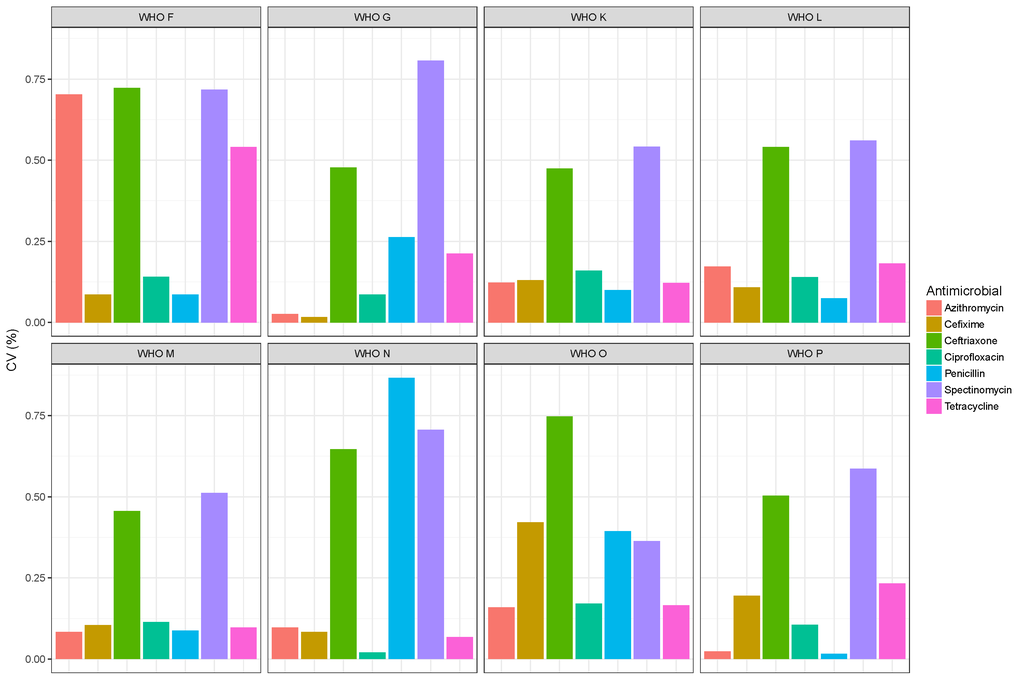

Figure S2. Intra assay coefficient of variation. To test the reproducibility of the resazurin MIC assay seven antimicrobials were tested on eight WHO reference strains (n=56). The mean and standard deviation of three independent experiments was calculated. The coefficient of variation (ratio of standard deviation over the mean) was calculated for sample. Barplots are shown for each sample. The mean of the coefficient of variation (intra assay CV) is 0.29.

### Hill coefficient statistics

|  | antibiotic | mean | sd | min | max |
| --- | --- | --- | --- | --- | --- |
| **3** | Ceftriaxone | 1.621 | 1.277 | 0.1166 | 7.455 |
| **2** | Cefixime | 1.916 | 1.539 | 0.1029 | 7.151 |
| **7** | Tetracycline | 2.091 | 0.8737 | 0.4026 | 7.818 |
| **5** | Penicillin | 2.498 | 1.674 | 0.3353 | 10.47 |
| **1** | Azithromycin | 2.598 | 1.494 | 0.6032 | 13.44 |
| **4** | Ciprofloxacin | 2.704 | 1.186 | 0.2596 | 7.733 |
| **6** | Spectinomycin | 2.899 | 1.713 | 0.3138 | 9.158 |

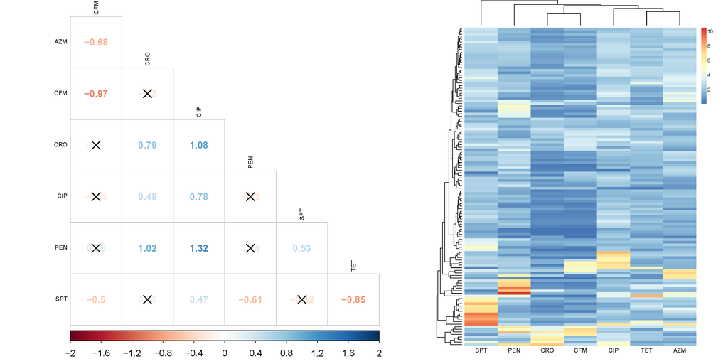

Figure S3. Difference of Hill coefficients. (a) The difference between the mean of 124 Hill coefficients (124 clinical strains examined) is shown for each antimicrobial combination. High values are shown in an increasingly intense blue colour gradient and low values in red. A pairwise t-test was performed and non-significant differences (p value > 0.05) marked with a black cross. (b) Hierarchical clustering of Hill coefficients. Rows represent Hill coefficients for different strains (N=124) and columns antimicrobials. The beta-lactams penicillin G, ceftriaxone and cefixime are more similar to each other than to the other antimicrobials.

### Example for Biphasic curves

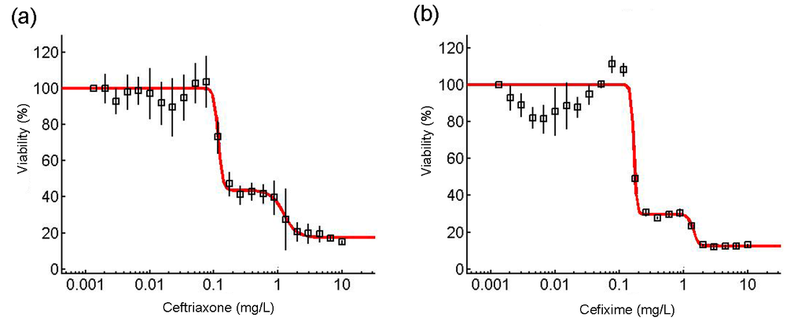

Figure S4. Biphasic dose response curves. The viability (%) was plotted against 24 different antimicrobial concentrations. Mean and standard error of three independent experiments are shown. (a) Ceftriaxone in Strain 11 (validation data). A biphasic model (red curve) fits the model better (bic=563) than a monophasic model (bic=794).1 The first EC50 is at 0.12 mg/L and the second at 1.21 mg/L (Etest MIC=0.125 mg/L). (b) Cefixime in Strain 11 (validation data). A biphasic model (red curve) fits the model better (bic=850) than a monophasic model (bic=8574). The first EC50 is at 0.16 mg/L and the second at 1.39 mg/L (Etest MIC=0.25 mg/L).